# Case Study Bellabeat

Akilan Sivanandham

2024-06-02

# Introduction

We will clean and manipulate this dataset to ensure accurate and reliable analysis. Our approach will involve creating visualizations and employing statistical models to identify trends and patterns within the data.

The analysis will provide actionable insights for Bellabeat, offering recommendations on how to refine its marketing strategy and enhance product development. Ultimately, our goal is to help Bellabeat better understand its customers and the market, enabling data-driven decisions on the following questions.

### Our main focus on following questions

- What are the primary patterns in Bellabeat smart device utlization?
- How can the above insights enhance Bellabeat on its marketing strategy and product development?
- What are the main opportunities and challenges that Bellabeat faces in the smart device industry?

### ASK

##### Task

Sršen has tasked you with analyzing smart device usage data to gain insights into how consumers use non-Bellabeat smart devices. Based on these insights, you are to select one Bellabeat product to focus on in your presentation

#### Loading packages

In order to proceed further we need to looad following packages in our R-Studio environment

```r
library(tidyverse)
```

```r
library(lubridate)
library(ggplot2)
library(dplyr)
library(stringr)
library(highcharter)
library(janitor)
library(RColorBrewer)
library(kableExtra)
library(scales)
library(readr)
```

#### Loading data

uploadig data in to dataset. due to number of files, we use following method to load all the data and create dataset with appropriate names.

```r
# Set the working directory which contain the download CSV files
setwd('Data/mturkfitbit_export_4.12.16-5.12.16/Fitabase Data 4.12.16-5.12.16')

# Get all the CSV files names from the folder.
csv_files <- list.files(pattern = '*.csv')

#Read CSV files functions
read_csv_files <- function(file_name){
  read_csv(file_name)
}

data_frame <- lapply(csv_files, read_csv_files)
#Create Data set name from the file

create_dataset_name <- function(file_name)
{
   name <- tools::file_path_sans_ext(basename(file_name))

   # Split the name by underscores
  name_parts <- unlist(strsplit(name, "_"))

  # Remove the last part if there are more than one part
  if (length(name_parts) > 1) {
    name_parts <- name_parts[-length(name_parts)]
  }

  # Combine the remaining parts
  name <- paste(name_parts, collapse = "_")


 # Insert underscores before capital letters and lowercase letters followed by capital letters
  name <- gsub("([a-z])([A-Z])", "\\1_\\2", name)    # Insert underscore between lowercase and uppercase
  name <- gsub("([A-Z])([A-Z][a-z])", "\\1_\\2", name) # Insert underscore before subsequent capital letters

  # Ensure all parts are capitalized correctly and join with underscores
  name_parts <- unlist(strsplit(name, "_"))
  name <- paste(name_parts, collapse = "_")

  name
}

# Assign data frames to dynamically created names
for (i in seq_along(csv_files)) {
  dataset_name <- create_dataset_name(csv_files[i])
  assign(dataset_name, data_frame[[i]], envir = .GlobalEnv)
}


# List the names of the created datasets
created_datasets <- sapply(csv_files, create_dataset_name)
print(created_datasets)
```

```
##     dailyActivity_merged.csv     dailyCalories_merged.csv
##             "daily_Activity"             "daily_Calories"
##  dailyIntensities_merged.csv        dailySteps_merged.csv
##          "daily_Intensities"                "daily_Steps"
## heartrate_seconds_merged.csv    hourlyCalories_merged.csv
##          "heartrate_seconds"            "hourly_Calories"
## hourlyIntensities_merged.csv       hourlySteps_merged.csv
##         "hourly_Intensities"               "hourly_Steps"
##          sleepDay_merged.csv     weightLogInfo_merged.csv
##                  "sleep_Day"            "weight_Log_Info"
```

```r
head(daily_Activity)
```

```
## # A tibble: 6 × 15
##           Id ActivityDate TotalSteps TotalDistance TrackerDistance
##        <dbl> <chr>             <dbl>         <dbl>           <dbl>
## 1 1503960366 4/12/2016         13162          8.5             8.5
## 2 1503960366 4/13/2016         10735          6.97            6.97
## 3 1503960366 4/14/2016         10460          6.74            6.74
## 4 1503960366 4/15/2016          9762          6.28            6.28
## 5 1503960366 4/16/2016         12669          8.16            8.16
## 6 1503960366 4/17/2016          9705          6.48            6.48
## # ℹ 10 more variables: LoggedActivitiesDistance <dbl>,
## #   VeryActiveDistance <dbl>, ModeratelyActiveDistance <dbl>,
## #   LightActiveDistance <dbl>, SedentaryActiveDistance <dbl>,
## #   VeryActiveMinutes <dbl>, FairlyActiveMinutes <dbl>,
## #   LightlyActiveMinutes <dbl>, SedentaryMinutes <dbl>, Calories <dbl>
```

### Process

Lets check the glimpse of data, to understand the data and its type.

```r
# Glimpse of all datasets
for (dataset_name in created_datasets) {
  cat("Dataset:", dataset_name, "\n")
  glimpse(get(dataset_name))
  cat("\n\n")
}
```

```
## Dataset: daily_Activity
## Rows: 940
## Columns: 15
## $ Id                       <dbl> 1503960366, 1503960366, 1503960366, 150396036…
## $ ActivityDate             <chr> "4/12/2016", "4/13/2016", "4/14/2016", "4/15/…
## $ TotalSteps               <dbl> 13162, 10735, 10460, 9762, 12669, 9705, 13019…
## $ TotalDistance            <dbl> 8.50, 6.97, 6.74, 6.28, 8.16, 6.48, 8.59, 9.8…
## $ TrackerDistance          <dbl> 8.50, 6.97, 6.74, 6.28, 8.16, 6.48, 8.59, 9.8…
## $ LoggedActivitiesDistance <dbl> 0, 0, 0, 0, 0, 0, 0, 0, 0, 0, 0, 0, 0, 0, 0, …
## $ VeryActiveDistance       <dbl> 1.88, 1.57, 2.44, 2.14, 2.71, 3.19, 3.25, 3.5…
## $ ModeratelyActiveDistance <dbl> 0.55, 0.69, 0.40, 1.26, 0.41, 0.78, 0.64, 1.3…
## $ LightActiveDistance      <dbl> 6.06, 4.71, 3.91, 2.83, 5.04, 2.51, 4.71, 5.0…
## $ SedentaryActiveDistance  <dbl> 0, 0, 0, 0, 0, 0, 0, 0, 0, 0, 0, 0, 0, 0, 0, …
## $ VeryActiveMinutes        <dbl> 25, 21, 30, 29, 36, 38, 42, 50, 28, 19, 66, 4…
## $ FairlyActiveMinutes      <dbl> 13, 19, 11, 34, 10, 20, 16, 31, 12, 8, 27, 21…
## $ LightlyActiveMinutes     <dbl> 328, 217, 181, 209, 221, 164, 233, 264, 205, …
## $ SedentaryMinutes         <dbl> 728, 776, 1218, 726, 773, 539, 1149, 775, 818…
## $ Calories                 <dbl> 1985, 1797, 1776, 1745, 1863, 1728, 1921, 203…
##
##
## Dataset: daily_Calories
## Rows: 940
## Columns: 3
## $ Id          <dbl> 1503960366, 1503960366, 1503960366, 1503960366, 1503960366…
## $ ActivityDay <chr> "4/12/2016", "4/13/2016", "4/14/2016", "4/15/2016", "4/16/…
## $ Calories    <dbl> 1985, 1797, 1776, 1745, 1863, 1728, 1921, 2035, 1786, 1775…
##
##
## Dataset: daily_Intensities
## Rows: 940
## Columns: 10
## $ Id                       <dbl> 1503960366, 1503960366, 1503960366, 150396036…
## $ ActivityDay              <chr> "4/12/2016", "4/13/2016", "4/14/2016", "4/15/…
## $ SedentaryMinutes         <dbl> 728, 776, 1218, 726, 773, 539, 1149, 775, 818…
## $ LightlyActiveMinutes     <dbl> 328, 217, 181, 209, 221, 164, 233, 264, 205, …
## $ FairlyActiveMinutes      <dbl> 13, 19, 11, 34, 10, 20, 16, 31, 12, 8, 27, 21…
## $ VeryActiveMinutes        <dbl> 25, 21, 30, 29, 36, 38, 42, 50, 28, 19, 66, 4…
## $ SedentaryActiveDistance  <dbl> 0, 0, 0, 0, 0, 0, 0, 0, 0, 0, 0, 0, 0, 0, 0, …
## $ LightActiveDistance      <dbl> 6.06, 4.71, 3.91, 2.83, 5.04, 2.51, 4.71, 5.0…
## $ ModeratelyActiveDistance <dbl> 0.55, 0.69, 0.40, 1.26, 0.41, 0.78, 0.64, 1.3…
```

[output cut: 50 more lines]

```
## $ TotalMinutesAsleep <dbl> 327, 384, 412, 340, 700, 304, 360, 325, 361, 430, 2…
## $ TotalTimeInBed     <dbl> 346, 407, 442, 367, 712, 320, 377, 364, 384, 449, 3…
##
##
## Dataset: weight_Log_Info
## Rows: 67
## Columns: 8
## $ Id             <dbl> 1503960366, 1503960366, 1927972279, 2873212765, 2873212…
## $ Date           <chr> "5/2/2016 11:59:59 PM", "5/3/2016 11:59:59 PM", "4/13/2…
## $ WeightKg       <dbl> 52.6, 52.6, 133.5, 56.7, 57.3, 72.4, 72.3, 69.7, 70.3, …
## $ WeightPounds   <dbl> 115.9631, 115.9631, 294.3171, 125.0021, 126.3249, 159.6…
## $ Fat            <dbl> 22, NA, NA, NA, NA, 25, NA, NA, NA, NA, NA, NA, NA, NA,…
## $ BMI            <dbl> 22.65, 22.65, 47.54, 21.45, 21.69, 27.45, 27.38, 27.25,…
## $ IsManualReport <lgl> TRUE, TRUE, FALSE, TRUE, TRUE, TRUE, TRUE, TRUE, TRUE, …
## $ LogId          <dbl> 1.462234e+12, 1.462320e+12, 1.460510e+12, 1.461283e+12,…
```

#### Split the Date and time for Datasets.

In order to process further, we need to split date and time from the following dataset in differnt column.

- *heartrate_seconds* - Dataset about the information of heart rate by seconds
- *hourly_Calories* - Dataset about the information of Calories by hourly
- *hourly_Intensities* - Dataset about the information of Intensities by hourly
- *hourly_Steps* - Dataset about the information of Steps by hourly
- *sleep_Day* - Dataset about the information of Sleeping hours by day
- *weight_Log_Info* - Dataset about the information of Weight

```r
# heartrate_seconds
heartrate_seconds$Time = as.POSIXct(heartrate_seconds$Time,format="%m/%d/%Y %I:%M:%S %p", tz=Sys.timezone())
heartrate_seconds$date <- format(heartrate_seconds$Time, format = "%m/%d/%y")
heartrate_seconds$time <- format(heartrate_seconds$Time, format = "%H:%M:%S")
glimpse(heartrate_seconds)
```

```
## Rows: 2,483,658
## Columns: 5
## $ Id    <dbl> 2022484408, 2022484408, 2022484408, 2022484408, 2022484408, 2022…
## $ Time  <dttm> 2016-04-12 07:21:00, 2016-04-12 07:21:05, 2016-04-12 07:21:10, …
## $ Value <dbl> 97, 102, 105, 103, 101, 95, 91, 93, 94, 93, 92, 89, 83, 61, 60, …
## $ date  <chr> "04/12/16", "04/12/16", "04/12/16", "04/12/16", "04/12/16", "04/…
## $ time  <chr> "07:21:00", "07:21:05", "07:21:10", "07:21:20", "07:21:25", "07:…
```

```r
head(heartrate_seconds)
```

```
## # A tibble: 6 × 5
##           Id Time                Value date     time
##        <dbl> <dttm>              <dbl> <chr>    <chr>
## 1 2022484408 2016-04-12 07:21:00    97 04/12/16 07:21:00
## 2 2022484408 2016-04-12 07:21:05   102 04/12/16 07:21:05
## 3 2022484408 2016-04-12 07:21:10   105 04/12/16 07:21:10
## 4 2022484408 2016-04-12 07:21:20   103 04/12/16 07:21:20
## 5 2022484408 2016-04-12 07:21:25   101 04/12/16 07:21:25
## 6 2022484408 2016-04-12 07:22:05    95 04/12/16 07:22:05
```

```r
#hourly_Calories
hourly_Calories$ActivityHour = as.POSIXct(hourly_Calories$ActivityHour,format="%m/%d/%Y %I:%M:%S %p", tz=Sys.timezone())
hourly_Calories$date <- format(hourly_Calories$ActivityHour, format = "%m/%d/%y")
hourly_Calories$time<- format(hourly_Calories$ActivityHour, format = "%H:%M:%S")
glimpse(hourly_Calories)
```

```
## Rows: 22,099
## Columns: 5
## $ Id           <dbl> 1503960366, 1503960366, 1503960366, 1503960366, 150396036…
## $ ActivityHour <dttm> 2016-04-12 00:00:00, 2016-04-12 01:00:00, 2016-04-12 02:…
## $ Calories     <dbl> 81, 61, 59, 47, 48, 48, 48, 47, 68, 141, 99, 76, 73, 66, …
## $ date         <chr> "04/12/16", "04/12/16", "04/12/16", "04/12/16", "04/12/16…
## $ time         <chr> "00:00:00", "01:00:00", "02:00:00", "03:00:00", "04:00:00…
```

```r
head(hourly_Calories)
```

```
## # A tibble: 6 × 5
##           Id ActivityHour        Calories date     time
##        <dbl> <dttm>                 <dbl> <chr>    <chr>
## 1 1503960366 2016-04-12 00:00:00       81 04/12/16 00:00:00
## 2 1503960366 2016-04-12 01:00:00       61 04/12/16 01:00:00
## 3 1503960366 2016-04-12 02:00:00       59 04/12/16 02:00:00
## 4 1503960366 2016-04-12 03:00:00       47 04/12/16 03:00:00
## 5 1503960366 2016-04-12 04:00:00       48 04/12/16 04:00:00
## 6 1503960366 2016-04-12 05:00:00       48 04/12/16 05:00:00
```

```r
#hourly_Intensities
hourly_Intensities$ActivityHour=as.POSIXct(hourly_Intensities$ActivityHour,format="%m/%d/%Y %I:%M:%S %p", tz=Sys.timezone())
hourly_Intensities$date <- format(hourly_Intensities$ActivityHour, format = "%m/%d/%y")
hourly_Intensities$time<- format(hourly_Intensities$ActivityHour, format = "%H:%M:%S")
glimpse(hourly_Intensities)
```

```
## Rows: 22,099
## Columns: 6
## $ Id               <dbl> 1503960366, 1503960366, 1503960366, 1503960366, 15039…
## $ ActivityHour     <dttm> 2016-04-12 00:00:00, 2016-04-12 01:00:00, 2016-04-12…
## $ TotalIntensity   <dbl> 20, 8, 7, 0, 0, 0, 0, 0, 13, 30, 29, 12, 11, 6, 36, 5…
## $ AverageIntensity <dbl> 0.333333, 0.133333, 0.116667, 0.000000, 0.000000, 0.0…
## $ date             <chr> "04/12/16", "04/12/16", "04/12/16", "04/12/16", "04/1…
## $ time             <chr> "00:00:00", "01:00:00", "02:00:00", "03:00:00", "04:0…
```

```r
head(hourly_Intensities)
```

```
## # A tibble: 6 × 6
##           Id ActivityHour        TotalIntensity AverageIntensity date     time
##        <dbl> <dttm>                       <dbl>            <dbl> <chr>    <chr>
## 1 1503960366 2016-04-12 00:00:00             20            0.333 04/12/16 00:00…
## 2 1503960366 2016-04-12 01:00:00              8            0.133 04/12/16 01:00…
## 3 1503960366 2016-04-12 02:00:00              7            0.117 04/12/16 02:00…
## 4 1503960366 2016-04-12 03:00:00              0            0     04/12/16 03:00…
## 5 1503960366 2016-04-12 04:00:00              0            0     04/12/16 04:00…
## 6 1503960366 2016-04-12 05:00:00              0            0     04/12/16 05:00…
```

```r
#sleep_Day
sleep_Day$SleepDay=as.POSIXct(sleep_Day$SleepDay, format="%m/%d/%Y %I:%M:%S %p", tz=Sys.timezone())
sleep_Day$date <- format(sleep_Day$SleepDay, format = "%m/%d/%y")
sleep_Day$time <- format(sleep_Day$SleepDay, format = "%H:%M:%S")
glimpse(sleep_Day)
```

```
## Rows: 413
## Columns: 7
## $ Id                 <dbl> 1503960366, 1503960366, 1503960366, 1503960366, 150…
## $ SleepDay           <dttm> 2016-04-12, 2016-04-13, 2016-04-15, 2016-04-16, 20…
## $ TotalSleepRecords  <dbl> 1, 2, 1, 2, 1, 1, 1, 1, 1, 1, 1, 1, 1, 1, 1, 1, 1, …
## $ TotalMinutesAsleep <dbl> 327, 384, 412, 340, 700, 304, 360, 325, 361, 430, 2…
## $ TotalTimeInBed     <dbl> 346, 407, 442, 367, 712, 320, 377, 364, 384, 449, 3…
## $ date               <chr> "04/12/16", "04/13/16", "04/15/16", "04/16/16", "04…
## $ time               <chr> "00:00:00", "00:00:00", "00:00:00", "00:00:00", "00…
```

```r
head(sleep_Day)
```

```
## # A tibble: 6 × 7
##       Id SleepDay            TotalSleepRecords TotalMinutesAsleep TotalTimeInBed
##    <dbl> <dttm>                          <dbl>              <dbl>          <dbl>
## 1 1.50e9 2016-04-12 00:00:00                 1                327            346
## 2 1.50e9 2016-04-13 00:00:00                 2                384            407
## 3 1.50e9 2016-04-15 00:00:00                 1                412            442
## 4 1.50e9 2016-04-16 00:00:00                 2                340            367
## 5 1.50e9 2016-04-17 00:00:00                 1                700            712
## 6 1.50e9 2016-04-19 00:00:00                 1                304            320
## # ℹ 2 more variables: date <chr>, time <chr>
```

```r
#hourly_Steps
hourly_Steps$ActivityHour=as.POSIXct(hourly_Steps$ActivityHour, format="%m/%d/%Y %I:%M:%S %p", tz=Sys.timezone())
hourly_Steps$date <- format(hourly_Steps$ActivityHour, format = "%m/%d/%y")
hourly_Steps$time <- format(hourly_Steps$ActivityHour, format = "%H:%M:%S")
glimpse(hourly_Steps)
```

```
## Rows: 22,099
## Columns: 5
## $ Id           <dbl> 1503960366, 1503960366, 1503960366, 1503960366, 150396036…
## $ ActivityHour <dttm> 2016-04-12 00:00:00, 2016-04-12 01:00:00, 2016-04-12 02:…
## $ StepTotal    <dbl> 373, 160, 151, 0, 0, 0, 0, 0, 250, 1864, 676, 360, 253, 2…
## $ date         <chr> "04/12/16", "04/12/16", "04/12/16", "04/12/16", "04/12/16…
## $ time         <chr> "00:00:00", "01:00:00", "02:00:00", "03:00:00", "04:00:00…
```

```r
head(hourly_Steps)
```

```
## # A tibble: 6 × 5
##           Id ActivityHour        StepTotal date     time
##        <dbl> <dttm>                  <dbl> <chr>    <chr>
## 1 1503960366 2016-04-12 00:00:00       373 04/12/16 00:00:00
## 2 1503960366 2016-04-12 01:00:00       160 04/12/16 01:00:00
## 3 1503960366 2016-04-12 02:00:00       151 04/12/16 02:00:00
## 4 1503960366 2016-04-12 03:00:00         0 04/12/16 03:00:00
## 5 1503960366 2016-04-12 04:00:00         0 04/12/16 04:00:00
## 6 1503960366 2016-04-12 05:00:00         0 04/12/16 05:00:00
```

```r
#
weight_Log_Info$Date=as.POSIXct(weight_Log_Info$Date, format="%m/%d/%Y %I:%M:%S %p", tz=Sys.timezone())
weight_Log_Info$date <- format(weight_Log_Info$Date, format = "%m/%d/%y")
weight_Log_Info$time <- format(weight_Log_Info$Date, format = "%H:%M:%S")
glimpse(weight_Log_Info)
```

```
## Rows: 67
## Columns: 10
## $ Id             <dbl> 1503960366, 1503960366, 1927972279, 2873212765, 2873212…
## $ Date           <dttm> 2016-05-02 23:59:59, 2016-05-03 23:59:59, 2016-04-13 0…
## $ WeightKg       <dbl> 52.6, 52.6, 133.5, 56.7, 57.3, 72.4, 72.3, 69.7, 70.3, …
## $ WeightPounds   <dbl> 115.9631, 115.9631, 294.3171, 125.0021, 126.3249, 159.6…
## $ Fat            <dbl> 22, NA, NA, NA, NA, 25, NA, NA, NA, NA, NA, NA, NA, NA,…
## $ BMI            <dbl> 22.65, 22.65, 47.54, 21.45, 21.69, 27.45, 27.38, 27.25,…
## $ IsManualReport <lgl> TRUE, TRUE, FALSE, TRUE, TRUE, TRUE, TRUE, TRUE, TRUE, …
## $ LogId          <dbl> 1.462234e+12, 1.462320e+12, 1.460510e+12, 1.461283e+12,…
## $ date           <chr> "05/02/16", "05/03/16", "04/13/16", "04/21/16", "05/12/…
## $ time           <chr> "23:59:59", "23:59:59", "01:08:52", "23:59:59", "23:59:…
```

```r
head(weight_Log_Info)
```

```
## # A tibble: 6 × 10
##          Id Date                WeightKg WeightPounds   Fat   BMI IsManualReport
##       <dbl> <dttm>                 <dbl>        <dbl> <dbl> <dbl> <lgl>
## 1    1.50e9 2016-05-02 23:59:59     52.6         116.    22  22.6 TRUE
## 2    1.50e9 2016-05-03 23:59:59     52.6         116.    NA  22.6 TRUE
## 3    1.93e9 2016-04-13 01:08:52    134.          294.    NA  47.5 FALSE
## 4    2.87e9 2016-04-21 23:59:59     56.7         125.    NA  21.5 TRUE
## 5    2.87e9 2016-05-12 23:59:59     57.3         126.    NA  21.7 TRUE
## 6    4.32e9 2016-04-17 23:59:59     72.4         160.    25  27.5 TRUE
## # ℹ 3 more variables: LogId <dbl>, date <chr>, time <chr>
```

#### Cleaning Data

Checking for duplicates and removing it.

```r
# loop
for(dataset_name in created_datasets)
{
  cat("Dataset:", dataset_name, "\n")
  df <- get(dataset_name)

  initial_rows <- nrow(df) # get the number of rows before the process
  df <- df %>% distinct() # remove duplicates
  final_rows <- nrow(df) # get the number of rows after the process


  duplicates_removed <- initial_rows - final_rows

  cat("Initial rows:", initial_rows, "\n")

  cat("Final rows:", final_rows, "\n")
  cat("Duplicates removed:", duplicates_removed, "\n\n")

  assign(dataset_name, df, envir = .GlobalEnv) # assign the cleaned dataset to the environment

}
```

```
## Dataset: daily_Activity
## Initial rows: 940
## Final rows: 940
## Duplicates removed: 0
##
## Dataset: daily_Calories
## Initial rows: 940
## Final rows: 940
## Duplicates removed: 0
##
## Dataset: daily_Intensities
## Initial rows: 940
## Final rows: 940
## Duplicates removed: 0
##
## Dataset: daily_Steps
## Initial rows: 940
## Final rows: 940
## Duplicates removed: 0
##
## Dataset: heartrate_seconds
## Initial rows: 2483658
## Final rows: 2483658
## Duplicates removed: 0
##
## Dataset: hourly_Calories
## Initial rows: 22099
## Final rows: 22099
## Duplicates removed: 0
##
## Dataset: hourly_Intensities
## Initial rows: 22099
## Final rows: 22099
## Duplicates removed: 0
##
## Dataset: hourly_Steps
## Initial rows: 22099
## Final rows: 22099
## Duplicates removed: 0
##
## Dataset: sleep_Day
## Initial rows: 413
## Final rows: 410
## Duplicates removed: 3
##
## Dataset: weight_Log_Info
## Initial rows: 67
## Final rows: 67
## Duplicates removed: 0
```

#### Unique data

Next we need to find number of unique data present in the dataset

```r
for(dataset_name in created_datasets)
{
  cat("Dataset:", dataset_name, "\n")
  df <- get(dataset_name)
  num_unique <- n_distinct(df$Id)
  cat("Number of Unique values in 'Id':", num_unique, "\n\n")

}
```

```
## Dataset: daily_Activity
## Number of Unique values in 'Id': 33
##
## Dataset: daily_Calories
## Number of Unique values in 'Id': 33
##
## Dataset: daily_Intensities
## Number of Unique values in 'Id': 33
##
## Dataset: daily_Steps
## Number of Unique values in 'Id': 33
##
## Dataset: heartrate_seconds
## Number of Unique values in 'Id': 14
##
## Dataset: hourly_Calories
## Number of Unique values in 'Id': 33
##
## Dataset: hourly_Intensities
## Number of Unique values in 'Id': 33
##
## Dataset: hourly_Steps
## Number of Unique values in 'Id': 33
##
## Dataset: sleep_Day
## Number of Unique values in 'Id': 24
##
## Dataset: weight_Log_Info
## Number of Unique values in 'Id': 8
```

From the above findings **heartrate_seconds, sleep_Day and weight_Log_Info** have some inconsistency in data.

Especially **heartrate_seconds,** **weight_Log_Info** have only 14 and 8 unique id respectively, it can be biased data. so, this two are not reliable to analyze further.

#### Merge data

while exploring data, Daily Activity(daily_Activity) have all the informations except sleep data (sleep_day), so we need to combain those data. In order to do that we need to check compactablity of column names

```r
colnames(daily_Activity)
```

```
##  [1] "Id"                       "ActivityDate"
##  [3] "TotalSteps"               "TotalDistance"
##  [5] "TrackerDistance"          "LoggedActivitiesDistance"
##  [7] "VeryActiveDistance"       "ModeratelyActiveDistance"
##  [9] "LightActiveDistance"      "SedentaryActiveDistance"
## [11] "VeryActiveMinutes"        "FairlyActiveMinutes"
## [13] "LightlyActiveMinutes"     "SedentaryMinutes"
## [15] "Calories"
```

```r
colnames(sleep_Day)
```

```
## [1] "Id"                 "SleepDay"           "TotalSleepRecords"
## [4] "TotalMinutesAsleep" "TotalTimeInBed"     "date"
## [7] "time"
```

```r
# Ensure the date columns are in the same format
daily_Activity <- daily_Activity %>%
  mutate(ActivityDate = as.Date(ActivityDate, format = "%m/%d/%Y"))

# Merge the datasets on the 'Id' and corresponding date columns
daily_Activity_Sleep_merged <- merge(daily_Activity, sleep_Day, by.x = c("Id", "ActivityDate"), by.y = c("Id", "date"), all = TRUE)

# Print the merged dataset
head(daily_Activity_Sleep_merged)
```

```
##           Id ActivityDate TotalSteps TotalDistance TrackerDistance
## 1 1503960366   0004-12-16         NA            NA              NA
## 2 1503960366   0005-01-16         NA            NA              NA
## 3 1503960366   0005-02-16         NA            NA              NA
## 4 1503960366   0005-03-16         NA            NA              NA
## 5 1503960366   0005-05-16         NA            NA              NA
## 6 1503960366   0005-06-16         NA            NA              NA
##   LoggedActivitiesDistance VeryActiveDistance ModeratelyActiveDistance
## 1                       NA                 NA                       NA
## 2                       NA                 NA                       NA
## 3                       NA                 NA                       NA
## 4                       NA                 NA                       NA
## 5                       NA                 NA                       NA
## 6                       NA                 NA                       NA
##   LightActiveDistance SedentaryActiveDistance VeryActiveMinutes
```

[output cut: 20 more lines]

#### Weekday calculation

```r
# Add weekday column and order it
weekday_Avg <- daily_Activity %>%
  mutate(weekday = weekdays(ActivityDate)) %>%
  mutate(weekday = factor(weekday, levels = c("Monday", "Tuesday", "Wednesday", "Thursday", "Friday", "Saturday", "Sunday"), ordered = TRUE))

# Calculate average daily calories and steps for each weekday
weekday_Avg <- weekday_Avg %>%
  group_by(weekday) %>%
  summarize(
    AvgDaily_Cal = mean(Calories, na.rm = TRUE),
    AvgDaily_Steps = mean(TotalSteps, na.rm = TRUE)
  )
```

### Analysis

Our data ready for analyse phase

#### Summary

Sleep summary on daily_Activity_Sleep_merged

```r
daily_Activity_Sleep_merged %>%
  mutate(TotalHoursAsleep = TotalMinutesAsleep / 60, TotalHoursInBed = TotalTimeInBed /60) %>%
  select(TotalHoursAsleep, TotalHoursInBed) %>%
  summary()
```

```
##  TotalHoursAsleep  TotalHoursInBed
##  Min.   : 0.9667   Min.   : 1.017
##  1st Qu.: 6.0167   1st Qu.: 6.729
##  Median : 7.2083   Median : 7.717
##  Mean   : 6.9862   Mean   : 7.641
##  3rd Qu.: 8.1667   3rd Qu.: 8.767
##  Max.   :13.2667   Max.   :16.017
##  NA's   :940       NA's   :940
```

From the above finding, average hours of sleep is 6.9, which is very close to the recommended hours of sleep.

Daily Activity Summary

```r
daily_Activity %>% select(LightlyActiveMinutes, FairlyActiveMinutes, VeryActiveMinutes) %>% summary()
```

```
##  LightlyActiveMinutes FairlyActiveMinutes VeryActiveMinutes
##  Min.   :  0.0        Min.   :  0.00      Min.   :  0.00
##  1st Qu.:127.0        1st Qu.:  0.00      1st Qu.:  0.00
##  Median :199.0        Median :  6.00      Median :  4.00
##  Mean   :192.8        Mean   : 13.56      Mean   : 21.16
##  3rd Qu.:264.0        3rd Qu.: 19.00      3rd Qu.: 32.00
##  Max.   :518.0        Max.   :143.00      Max.   :210.00
```

```r
daily_Activity %>% select( LightActiveDistance, ModeratelyActiveDistance, VeryActiveDistance) %>% summary()
```

```
##  LightActiveDistance ModeratelyActiveDistance VeryActiveDistance
##  Min.   : 0.000      Min.   :0.0000           Min.   : 0.000
##  1st Qu.: 1.945      1st Qu.:0.0000           1st Qu.: 0.000
##  Median : 3.365      Median :0.2400           Median : 0.210
##  Mean   : 3.341      Mean   :0.5675           Mean   : 1.503
##  3rd Qu.: 4.782      3rd Qu.:0.8000           3rd Qu.: 2.053
##  Max.   :10.710      Max.   :6.4800           Max.   :21.920
```

```r
daily_Activity%>% select(TotalSteps,Calories)%>% summary()
```

```
##    TotalSteps       Calories
##  Min.   :    0   Min.   :   0
##  1st Qu.: 3790   1st Qu.:1828
##  Median : 7406   Median :2134
##  Mean   : 7638   Mean   :2304
##  3rd Qu.:10727   3rd Qu.:2793
##  Max.   :36019   Max.   :4900
```

```r
daily_Activity%>% mutate(sedentaryHours = SedentaryMinutes /60) %>%
  select(sedentaryHours, SedentaryActiveDistance)%>%summary()
```

```
##  sedentaryHours  SedentaryActiveDistance
##  Min.   : 0.00   Min.   :0.000000
##  1st Qu.:12.16   1st Qu.:0.000000
##  Median :17.62   Median :0.000000
##  Mean   :16.52   Mean   :0.001606
##  3rd Qu.:20.49   3rd Qu.:0.000000
##  Max.   :24.00   Max.   :0.110000
```

Sedentary Hours on Average person is much higher than normal.

#### Steps taken vs Calories

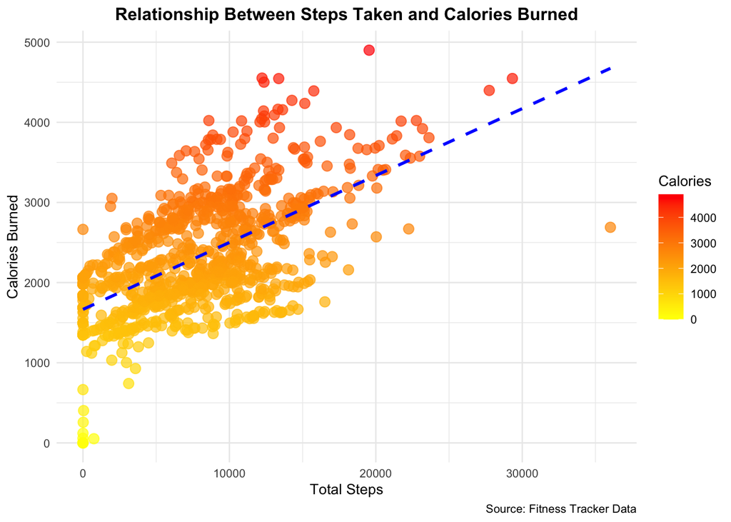

```r
ggplot(data = daily_Activity, mapping = aes(x = TotalSteps, y = Calories)) +
  geom_point(aes(colour = Calories), alpha = 0.7, size = 3) +
  geom_smooth(method = "lm", se = FALSE, colour = "blue", linetype = "dashed") +
  scale_color_gradient(low = "yellow", high = "red") +
  labs(
    title = "Relationship Between Steps Taken and Calories Burned",

    x = "Total Steps",
    y = "Calories Burned",
    caption = "Source: Fitness Tracker Data"
  ) +
  theme_minimal(base_size = 10) +
  theme(
    plot.title = element_text(face = "bold", hjust = 0.5),
    plot.subtitle = element_text(hjust = 0.5),
    legend.position = "right"
  )
```

This visualization effectively communicates the positive relationship between daily steps and calories burned, suggesting that increased physical activity, measured in steps, leads to higher calorie expenditure.

#### Compare different types of active minutes: VeryActiveMinutes, FairlyActiveMinutes, and LightlyActiveMinutes.

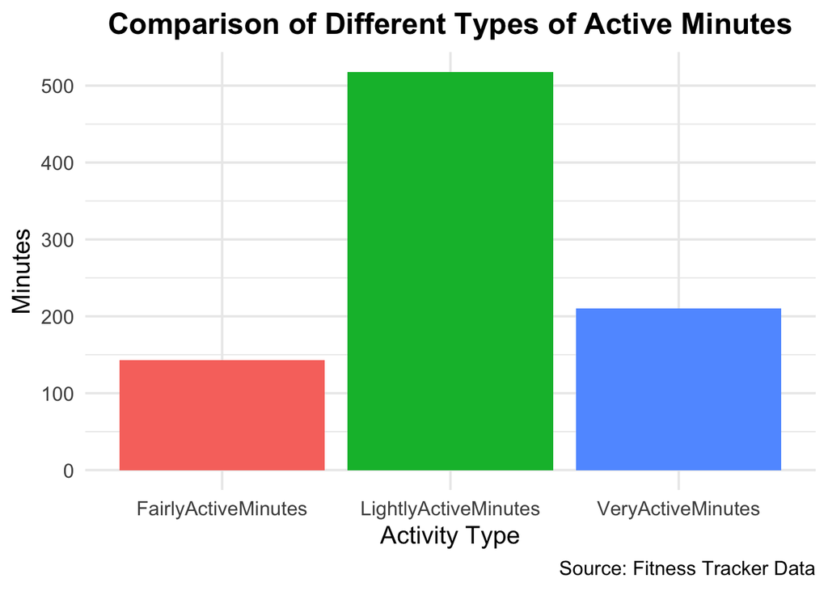

```r
active_minutes <- daily_Activity %>%
  select(Id, ActivityDate, VeryActiveMinutes, FairlyActiveMinutes, LightlyActiveMinutes) %>%
  gather(key = "ActivityType", value = "Minutes", VeryActiveMinutes, FairlyActiveMinutes, LightlyActiveMinutes)

ggplot(data = active_minutes, mapping = aes(x = ActivityType, y = Minutes, fill = ActivityType)) +
  geom_bar(stat = "identity", position = "dodge") +
  labs(
    title = "Comparison of Different Types of Active Minutes",
    x = "Activity Type",
    y = "Minutes",
    caption = "Source: Fitness Tracker Data"
  ) +
  theme_minimal(base_size = 15) +
  theme(
    plot.title = element_text(face = "bold", hjust = 0.5),
    plot.subtitle = element_text(hjust = 0.5),
    legend.position = "none"
  )
```

The bar plot compares different types of active minutes, including very active minutes, fairly active minutes, and lightly active minutes. By transforming the dataset, this visualization allows for a side-by-side comparison of how different intensities of activity contribute to overall physical activity. The plot provides insight into the distribution of various activity levels among the users, revealing that users spend more time in light active states compare to others.

#### Distribution of TotalDistance

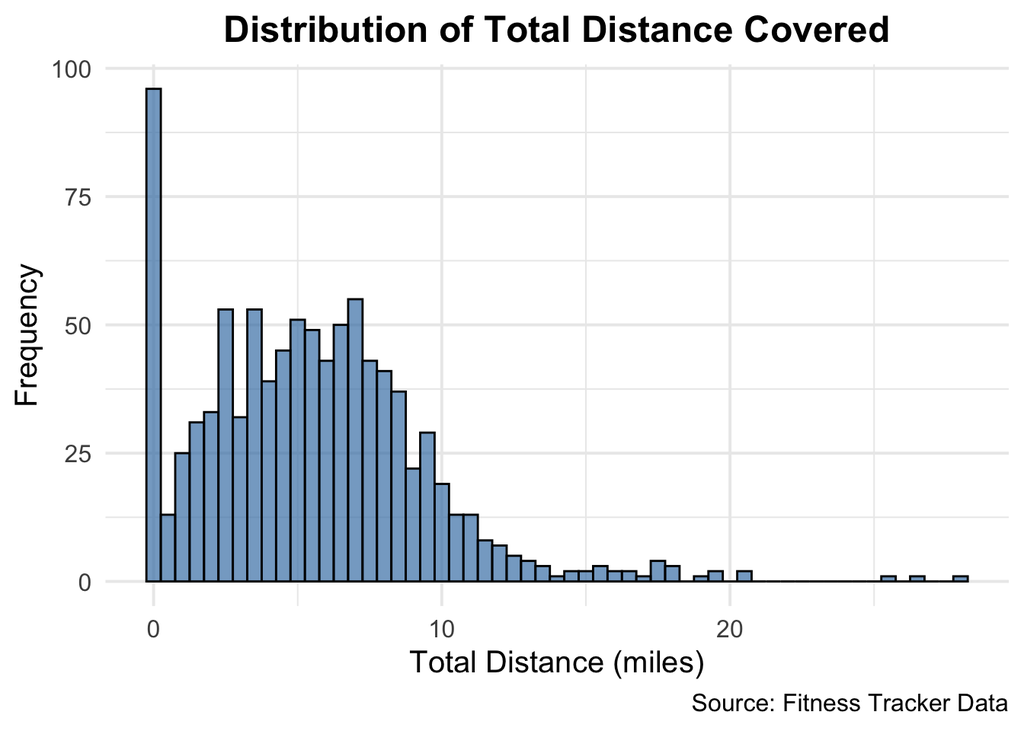

```r
ggplot(data = daily_Activity, mapping = aes(x = TotalDistance)) +
  geom_histogram(binwidth = 0.5, fill = "steelblue", color = "black", alpha = 0.7) +
  labs(
    title = "Distribution of Total Distance Covered",
    x = "Total Distance (miles)",
    y = "Frequency",
    caption = "Source: Fitness Tracker Data"
  ) +
  theme_minimal(base_size = 15) +
  theme(
    plot.title = element_text(face = "bold", hjust = 0.5),
    plot.subtitle = element_text(hjust = 0.5)
  )
```

This histogram displays the distribution of total distance covered by individuals. By binning the total distance into intervals, the plot shows the frequency of different distance ranges. This visualization helps identify common distance ranges covered by users and highlights the overall activity levels in terms of distance. It can reveal whether most users tend to walk short distances daily or if there are a significant number of users covering larger distances.

#### TotalSteps and Calories vary over ActivityDate

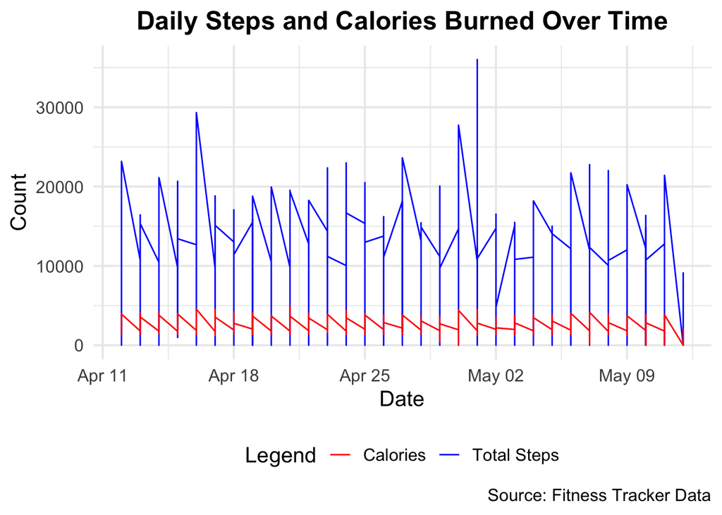

```r
daily_Activity <- daily_Activity %>%
  mutate(ActivityDate = as.Date(ActivityDate, format = "%m/%d/%Y"))

ggplot(data = daily_Activity, mapping = aes(x = ActivityDate)) +
  geom_line(aes(y = TotalSteps, color = "Total Steps")) +
  geom_line(aes(y = Calories, color = "Calories")) +
  scale_color_manual(values = c("Total Steps" = "blue", "Calories" = "red")) +
  labs(
    title = "Daily Steps and Calories Burned Over Time",
    x = "Date",
    y = "Count",
    color = "Legend",
    caption = "Source: Fitness Tracker Data"
  ) +
  theme_minimal(base_size = 15) +
  theme(
    plot.title = element_text(face = "bold", hjust = 0.5),
    plot.subtitle = element_text(hjust = 0.5),
    legend.position = "bottom"
  )
```

The line plot shows how total steps and calories burned vary over time, using the ActivityDate as the x-axis. By plotting both variables on the same graph, the plot provides a temporal view of the relationship between steps taken and calories burned. This visualization helps to identify trends and patterns in daily activity and calorie expenditure over time, such as seasonal variations, changes in activity levels, or the impact of specific events. The plot underscores the consistency or fluctuations in users’ physical activity and caloric burn.

#### Weekday

Average Daily Calories Burned and Steps Taken by Weekday

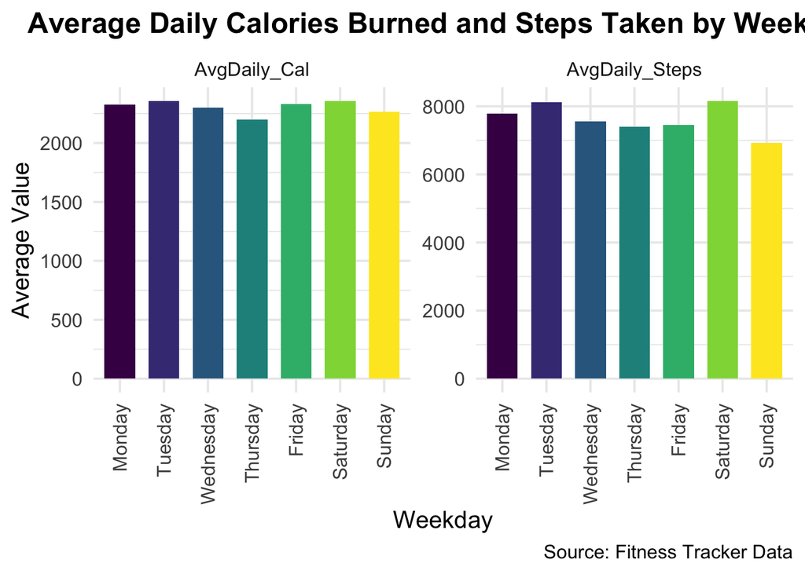

```r
# Reshape the data for faceting
weekday_Avg_long <- weekday_Avg %>%
  pivot_longer(cols = c(AvgDaily_Cal, AvgDaily_Steps), names_to = "Metric", values_to = "Value")

# Create a faceted bar plot
ggplot(data = weekday_Avg_long, aes(x = weekday, y = Value, fill = weekday)) +
  geom_bar(stat = "identity", position = "dodge", width = 0.7) +
  facet_wrap(~ Metric, scales = "free_y") +
  labs(
    title = "Average Daily Calories Burned and Steps Taken by Weekday",
    x = "Weekday",
    y = "Average Value",
    fill = "Metric",
    caption = "Source: Fitness Tracker Data"
  ) +
  theme_minimal(base_size = 15) +
  theme(
    plot.title = element_text(face = "bold", hjust = 0.5),
    legend.position = "none",
      axis.text.x = element_text(angle = 90, vjust = 0.5, hjust=1)
  )
```

### ACT

- BellaBeat could implement a feature to analyze users’ activity patterns and suggest personalized strategies to increase overall physical activity levels, such as taking short active breaks throughout the day or incorporating activities into daily routines.
- To promote better sleep quality, BellaBeat can offer personalized sleep hygiene tips and reminders, such as maintaining a consistent sleep schedule, creating a relaxing bedtime routine, and minimizing screen time before bed.
- BellaBeat can provide insights into users’ sedentary behavior and encourage them to break up prolonged sitting periods with brief movement breaks or light stretching exercises.
- Incorporating amification elements, BellaBeat could introduce challenges and rewards to motivate users to achieve their activity goals, fostering a sense of accomplishment and social interaction within the BellaBeat community.
- BellaBeat can leverage wearable technology to track users’ heart rate variability (HRV) and provide personalized stress management recommendations, such as breathing exercises, mindfulness practices, or guided relaxation sessions.
- To enhance accountability and motivation, BellaBeat could offer social sharing features, allowing users to connect with friends or join virtual fitness groups to share progress, provide encouragement, and participate in friendly competitions.
- BellaBeat can integrate with third-party fitness apps and devices to provide a comprehensive overview of users’ health and wellness data, enabling seamless synchronization and holistic insights into their lifestyle habits.
- BellaBeat could offer educational resources and articles on topics related to physical activity, nutrition, sleep, stress management, and overall well-being to empower users with knowledge and support informed decision-making.